# How Prestige Journals Remain Elite, Exclusive And Exclusionary

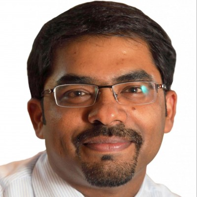

[Madhukar Pai](https://www.forbes.com/sites/madhukarpai/)Contributor

Opinions expressed by Forbes Contributors are their own.

[Healthcare](https://www.forbes.com/healthcare)

I write about global health, infectious diseases, and equity

[figure not shown]

Nature journals recently announced an author fee, €9500, which is thought to be the highest of any ... [+] journal. This news has been received with outrage and disappointment among scientists, especially researchers in low and middle income countries. AFP PHOTO LOIC VENANCE (Photo credit should read LOIC VENANCE/AFP via Getty Images)

AFP via Getty Images

Last week, *Nature* journals unveiled their “landmark” [open-access option](https://www.nature.com/articles/d41586-020-03324-y). Nature journals will charge authors, starting in January 2021, up to €9,500 (nearly US $11,400) to make research papers free to read, as an alternative to subscription-only publishing. Scientists from around the world received this news with outrage and disappointment on social media.

*Nature’s* announcement comes on the heels of their recent “[diversity commitment](https://www.springernature.com/gp/advancing-discovery/blog/blogposts/new-diversity-commitment/17485502)” which pledged “greater representation of currently under-represented groups” in their published content and events, and “faster movement in the direction of equity.”

How does *Nature’s* diversity commitment square with their own fee options? Do elite, prestige journals actually care about equity and diversity? Is *Nature*, one of the largest and most profitable publishers, leading in addressing inequities and setting an example to other publishers? And what do scientists in low- and middle-income countries (LMICs), people who are rarely consulted, think about *Nature’s* new policy?

To address these questions, I consulted 20+ scientists from around the world. Their voices matter, as scientists are the most important stakeholder in the publishing industry. I also sought input from Springer Nature, the publisher, to better understand their fee structure which is thought to be the [highest](https://www.sciencemag.org/news/2020/11/9500-nature-journals-will-now-make-your-paper-free-read) of any journal. *The Lancet*, another high-impact journal (by Elsevier, the publisher), in comparison, charges $5000 for the open-access option.

**Outraged & gobsmacked!**

“The fees are outrageous, an impediment to open access, and a huge hurdle for LMIC researchers,” said [Mwele Malecela](https://www.who.int/neglected_diseases/about/Dr-Mwelecele-Ntuli-Malecela-biosketch/en/), Director, Neglected Tropical Diseases, World Health Organization.

“It’s honestly enough to make one cry! I converted the amount to Kenya Shillings and I was gobsmacked,” said [Kui Muraya](https://kemri-wellcome.org/author/kmuray-a/), a scientist at the KEMRI-Wellcome Trust Research Programme in Kenya. [Benjamin Tsofa](https://kemri-wellcome.org/author/btsofa/), her colleague, agrees. “This is the net annual earning of some of our scientists in many African institutions,” he said.

“€9,500 is more than what a microbiologist/geneticist makes in a year in my country," said [Senjuti Saha](https://en.wikipedia.org/wiki/Senjuti_Saha), a scientist at the Child Health Research Foundation (CHRF) in Bangladesh. “€9,500 amounts to annual salary of an assistant professor in a medical school in India,” said [Shriprakash Kalantri](https://www.mgims.ac.in/index.php/academics/departments/item/sp-kalantri), a professor at the Mahatma Gandhi Institute of Medical Sciences in Sevagram, India.

‘So now a *Nature* publication for early-career LMIC researchers will not only mean meeting the ongoing challenge of doing world-class science in less-resourced settings, but will also mean that they will need to be able to pay - what is an exorbitant sum (close to a years’ salary) - to showcase their world-class work. That should take the pressure off having to publish in *Nature*!” said [Karishma Kaushik](https://www.karishmakaushiklab.com/), Assistant Professor, Institute of Bioinformatics and Biotechnology, University of Pune, India.

“If this is the cost of prestige, we can expect that no scientist from the global south will ever achieve that status. We already work with shoestring budgets and our priority is to fund the work on the ground,” said [Asha De Vos](https://about.me/ashadevos), a marine biologist, Nat Geo Explorer, and founder of [Oceanswell](https://oceanswell.org/) in Sri Lanka.

**Adding insult to injury**

Researchers in LMICs struggle with many issues that HIC researchers rarely think about. Grant funding is scarce, as is governmental and institutional support for science. Infrastructure is a perennial struggle - issues like power outages and poor internet connectivity are common. LMIC researchers also deal with [bias](https://blogs.bmj.com/bmj/2017/12/05/richard-smith-strong-evidence-of-bias-against-research-from-low-income-countries/) against their work. High publication fees are now seen as insult added to injury, especially as the Covid-19 pandemic is substantially [worsening poverty](https://www.worldbank.org/en/news/press-release/2020/10/07/covid-19-to-add-as-many-as-150-million-extreme-poor-by-2021#:~:text=The%20COVID%2D19%20pandemic%20is,severity%20of%20the%20economic%20contraction.) globally.

A recent article in *BMJ Global Health* emphasized how article processing charges (APCs) are [stalling the progress](https://gh.bmj.com/content/bmjgh/5/9/e003650.full.pdf) of African researchers. “That APCs are a barrier to quality research in the global south is an understatement- APCs are killing any zeal left (after enduring low research grant funding) of global south researchers to become competitive,” said [Justice Nonvignon](http://www.ug.edu.gh/hppm/staff/prof-justice-nonvignon), an associate professor at the University of Ghana School of Public Health. “I just received an email from a journal which has accepted my paper for publication, asking that I cough up $3,000 if I want others to read and recognize my work. I can't afford that. So, I guess my work could be published but hidden from the world,” he added.

“*Nature* might as well post a sign that says "LMICs scientists not welcome here", said [Catherine Kyobutungi](https://aphrc.org/person/catherine-kyobutungi/), Executive Director at the African Population and Health Research Center. “Nature is out of touch with reality. It is a daily struggle for institutions like ours to financially support our researchers to pay open access fees. A few funders pay these fees but only for papers coming out of projects they have funded. I don't know in which world *Nature* thinks it's okay to charge fees equal to or more than the small grants many LMICs researchers can access,” she added.

It is flawed reasoning to assume that LMIC researchers have big grants from agencies such as the Bill & Melinda Gates Foundation, NIH or the Wellcome Trust, to pay the high APCs. Most researchers, especially those working in LMICs, do not hold such grants. LMIC scientists often work with small grants and also do un-funded research studies. There is little room in their budgets to cover high APCs.

“While it is encouraging to see Springer Nature adopt more open access options within their suite of journals, achieving open access this way can come at too high a cost,” said [Ashley Farley](https://twitter.com/ashleydfarley?lang=en), Program Officer, Knowledge & Research Services, at the Bill & Melinda Gates Foundation. “Setting open access fees at this level can bar authors from LMICs from engaging in scientific discourse happening in well regarded journals because many potential authors from these nations lack funder support for open access fees,” she added. According to Farley, the Bill & Melinda Gates Foundation only pays APCs for about 2700 articles each year. This is a small fraction of all papers published.

"In Brazil, €9,500 is one quarter of the maximum funding allowed in basic research grants offered by our state or the federal government,” said [Ana Marcia de Sá Guimarães](http://www.lapam.icb.usp.br/), an assistant professor at the University of São Paulo. “In our scarce conditions, having to pay this amount is a socially unjust use of taxpayer money. How can I tell a tuberculosis patient participating in my study that I will pay more than 100 times her/his treatment to publish the study results? Or how can I tell an aspiring scientist that I cannot pay two years of her fellowship because we published in *Nature*? Sadly, this is not how I have envisioned the path towards a more inclusive and global research environment." she added.

[Anant Bhan](https://twitter.com/anantbhan?lang=en), an adjunct professor at Yenepoya University in India agrees. “Even if funders agree to pay these high fees, it will draw often scarce resources from being spent on research towards profitable publisher entities who benefit from publicly funded research, as well as free labor of authors and peer reviewers,” he said.

[Ifedayo Adetifa](https://kemri-wellcome.org/author/iadetifa/), a professor at the KEMRI-Wellcome Trust Research Programme in Kenya compared the Nature price tag with the size of small grants that are the norm in many LMICs. “*Nature’*s policy effectively excludes majority of researchers from LMICs,” he said. “This also begs the question, what else can a LMIC researcher do with €9,500? The Africa Oxford Travel Grant provides a maximum of £5000 support the establishment of new collaborations between researchers in African countries and their collaborators at the University of Oxford. The ISID still runs the $6000 small grants scheme. ESPID gives small grants of €10,000,” he listed.

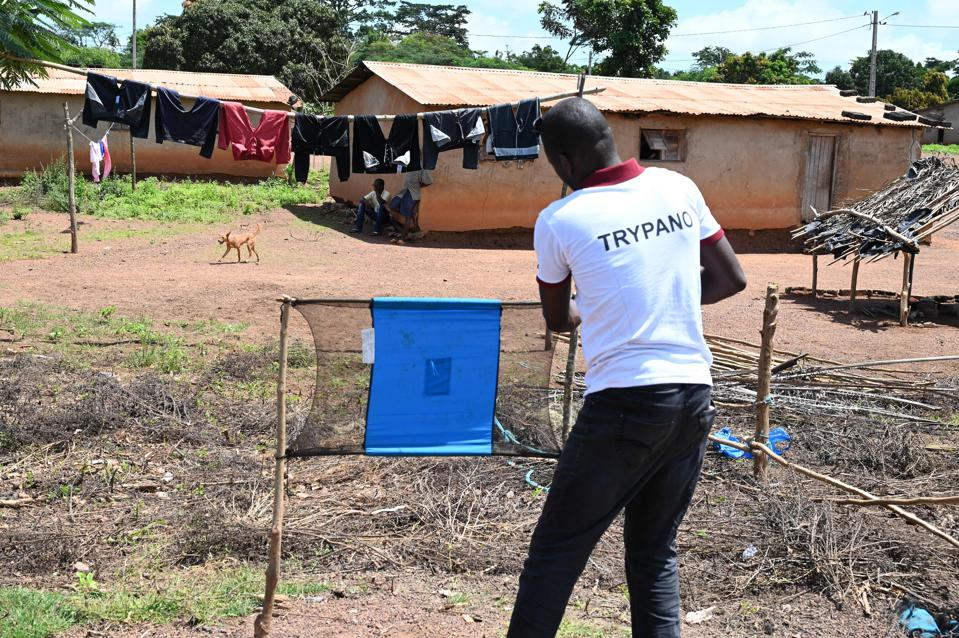

Scientists in low and middle-income countries work under many constraints, including low levels of ... [+] research funding (Photo by ISSOUF SANOGO / AFP) (Photo by ISSOUF SANOGO/AFP via Getty Images)

AFP via Getty Images

**Widening inequities**

Even without the high fees, most LMIC researchers believe Nature and similar prestige journals (e.g. *Lancet*, *BMJ*, *Science*, *Cell*, *New England Journal of Medicine*) are elitist institutions that [lack diversity](https://www.nytimes.com/2020/10/30/science/diversity-science-journals.html) at all levels (editors, editorial boards, peer reviewers and authors). Indeed, there are [studies](https://gh.bmj.com/content/4/5/e002018) which show lack of diversity in these journals. The high APC only reinforces the popular opinion that these journals only care about the rich and the privileged. But most journals, perhaps influenced by the Black Lives Matter movement, have pledged to do better with diversity and inclusion. Whether they are acting on such pledges is far from clear.

“The outrageous fee is counterintuitive to knowledge sharing, and will increase inequities in authorships, promoting exploitative collaborations in favor of well funded (mostly western) academic institutions, as LMIC researchers will not be able to afford being corresponding authors,” argued [Fyezah Jehan](https://www.who.int/maternal_child_adolescent/bio_fjehan/en/)**,** Associate Professor and Global Health Researcher at Aga Khan University in Pakistan.

[Thomas Scriba](http://www.idm.uct.ac.za/Thomas_Scriba), a professor at the University of Cape Town in South Africa has similar concerns. “This extraordinarily high publication cost will be unaffordable to most researchers from LMICs and is set to further exacerbate inequality based on wealth. This will further bias against publication of scientific results produced by LMIC institutions and organizations in *Nature* journals in favor of the HICs,” he said.

“When working in the medical humanitarian field and access to medicines, we understand that access to knowledge is already severely biased against scientists in the Global South who struggle to publish without an added burden of thousands paid by them for a journal. *Nature* might assume this would be provided by funders, but researchers from LMICs do not have the same access to funders, publishers, and other privileges,” said [Tammam Aloudat](https://twitter.com/tammamo?lang=en), MSF Access Campaign (Doctors Without Borders).

“Amidst the calls to democratize and decolonize global health, research is being expanded to not only include but to be led by civil society organizations and local advocacy groups. These groups use any funding to support local collectives and every dollar matters. How can they share their knowledge, when barriers to publish are as high as €10,000?” asked [Ngozi Erondu](https://www.ngozierondu.com/about) Senior Scholar, O’Neil Institute, Georgetown University.

**Publisher’s viewpoint**

I shared such concerns with [James Butcher](https://www.linkedin.com/in/jwbutcher), VP Journals, Nature Portfolio & BMC. He admitted that the transition of highly selective journals from a subscription model to a fully open access model “is challenging to do in a fair and equitable way.”

“We absolutely understand the very valid concerns about access to our journals for individuals from LMICs. We are committed to making the transition to open access for primary research because we believe in the power of open science to make a positive contribution to global society. However, we are only able to create the highest quality journals because of our large [in-house team](https://www.nature.com/documents/nr-inside-nature-infographic.pdf). There are 286 full time members of staff who work on primary research content (not news or reviews) on *Nature* and the *Nature* research journals, including 193 PhD trained editors who read and assess the 57,000 submissions that we receive each year, accepting 4500 of them for publication. The cost of those salaries — and of the staff who work in supporting functions like web development, HR and Legal — is currently largely born by institutional subscription revenues. We recognize the open access transition process will not be easy and that the APC price poses significant challenges to some authors, who will continue to be able to publish for free under the traditional subscription route for the foreseeable future. We are discussing whether there are any further steps we can take to support LMIC scientists in the interim,” added Butcher.

*Nature* also clarified that authors will continue to have the option to publish in any *Nature* journals through the current subscription-based publishing model, which does not incur publication fees. Readers, however, need to have individual or institutional subscriptions to download the content.

**How do we fix the broken publishing model?**

The problem with the publishing industry goes well beyond the latest *Nature* announcement. There is growing frustration within the scientific community about the current publishing model which clearly serves the publishers by delivering them [outrageous profit margins](https://www.theguardian.com/science/2017/jun/27/profitable-business-scientific-publishing-bad-for-science). But does the model work well for tax-payers, funders, universities, and scientists who do the actual science? A majority of scientists, funders and universities would argue the current model is not working for them and is ready for disruption.

“The core of science is that we are doing it to be read by others. Certainty not for the money - which is more than can be said for the journal publishers,” said [Neil Stone](https://twitter.com/DrNeilStone), an Infectious Diseases Consultant at University College London Hospital.

I agree. All scientists want to see their work read and used. As a scientist, I am sad when I find my publications behind pay-walls, more so since I work on tuberculosis which mostly affects LMICs. My biggest reward is that my science gets read, cited, and maybe put to use. While I have good access to journals today and am able to publish in prestigious journals, this was not the case when I lived and worked in India. So, I have seen, first-hand, the discriminations faced by LMIC researchers.

During this Covid-19 pandemic, the whole world has experienced (at least temporarily) the benefits of rapid access to science, [without paywalls](https://www.bloomberg.com/opinion/articles/2020-06-30/covid-19-shows-scientific-journals-like-elsevier-need-to-open-up). Increasingly, all funders and governments want research to be made available as open access, immediately upon publication ([Plan S](https://www.coalition-s.org/) is an example). This is to ensure that results of publicly-funded science reaches the tax-paying public immediately. [Universities](https://news.lib.berkeley.edu/oa-update) and [governments](https://www.editage.com/insights/norway-joins-the-ranks-of-germany-and-sweden-cancels-subscription-with-elsevier) have taken a hard stance against price-gouging by corporate publishers such as Elsevier and Springer Nature.

It is in this context that *Nature* announced its new open access pricing model, sparking outrage across the world. By doing so, they demonstrate tone deafness to all the concerns that have been repeatedly raised, and seem to have missed an opportunity to bring equity to an antiquated publishing model.

“Academic publication is a racket like no other - publishers take no risk, authors work hard to not only produce the research but also write the papers and peer review for free, while publishers make obscene amounts of profits,” said [Soumitra Pathare](https://cmhlp.org/team/soumitra-pathare/) Director, Centre for Mental Health Law & Policy in India.

Indeed, scientists and universities are tired of handing over their papers to publishers for free, and then paying big bucks to download them. Yes, quality costs, but does it need to cost so much that those who actually produce the work cannot access it themselves?

“This announcement from *Nature* reinforces yet again the unhealthy hold that commercial publishers have on academic publishing, which allows them to dictate the price for their services to an academic community that continues to have an unhealthy reliance on publishing in a small number of journals. These prices are just the latest step in a path that excludes large numbers of authors and which will if unchecked consolidate the inequity that exists in the scholarly publishing system. It is well past time for governments and academic institutions to work to develop national strategies and collaborate globally to re-establish the priorities for publishing that will serve the public good,” said [Virginia Barbour](https://www.coalition-s.org/logo/virginia-barbour/), Director, Australasian Open Access Strategy Group.

“The odds are already so unevenly stacked in favor of people who can afford a massive publication fee. It's just awful to see that unfair advantage stacked up even higher. So many people will have to choose between their work being accessible, or getting what a journal like *Nature* means to them,” said [Hilda Bastian](http://hildabastian.net/), a writer and independent meta-scientist. “Journals like Nature rely on the prestige that privileged institutions and research supported by prestige funders bring them. Those institutions and funders should put a serious cap on this and help end this inflation. €9,500 publication charges is not what public research money should be spent on,” she added.

“Nature must waive APCs for authors who have no means to pay them. If they do not, they will be replacing today’s current horrific inequity—in which only the rich can afford to read journal articles—with a different kind of inequity, in which only the rich can get published in journals,” said [Gavin Yamey](https://globalhealth.duke.edu/people/yamey-gavin), Professor of Global Health and Public Policy at Duke University.

**Academics & universities need to de-emphasize prestige journals**

Why do researchers continue to give so much importance to a handful of elite journals and inflate their importance? ‘”High impact journals such as *Nature* are well aware that publication in their journals is rightly or wrongly the currency of academic success. It can make or break careers. They appear to be exploiting this by charging astronomical open access fees,” said Neil Stone. Indeed, the publish or perish culture in academia, the obsession with “impact factors” and “citations” has made it possible for groups like Springer Nature and Elsevier to create highly ‘valued’ brands and exploit researchers and universities.

Researchers and universities need to counter this by changing tenure and promotion criteria and not be slavishly attached to prestige journals and big brands. Universities should stop paying bonuses and incentives for such prestige, vanity papers. Quality of the research should be more important than where it is published in the end. If this were to happen, the demand for elite, over-priced journals will wane.

[Manu Prakash](https://web.stanford.edu/group/prakash-lab/cgi-bin/labsite/), a professor at Stanford University, works on making science more accessible and teaches a course on [Frugal Science](https://www.frugalscience.org/). “We need to completely rethink publishing industry,” he said. “It was for a different era when information transfer and sharing was costly. It’s absurd beyond measure to think about the kind of fee they expect scientists to pay; to get published or even get the papers reviewed - while the actual review is literally done by the scientific community for free. But in the end, the publishing industry is just a reflection of the scientific establishment. So instead of pointing fingers; I would hope we all take a moment and look inwards. What can we do as individuals to bring change? What one single actionable item we can pick up to “make science more accessible, equitable to all.” We know voices of LMIC scientists matter, so how can we as individuals can support, encourage and bring the change we want to see?” he asked. “From everything I have seen over the last decade - I know it’s doable - one step at a time,” he answered.

**Exclusive and increasingly irrelevant?**

“The business model of elite academic publishing is exploitative, exclusionary, and unsustainable,” said [Seye Abimbola](https://www.sydney.edu.au/medicine-health/about/our-people/academic-staff/seye-abimbola.html), a professor at the University of Sydney. “The assumptions implicit in the current model is that it is a rich English-speaking world in which researchers are richly supported for their work, and the work of peer reviewers is without value, and knowledge is a good that could be traded as a private commodity. This is just not true. These assumptions fly in the face of reality. For example, most academic research is publicly funded, most of the knowledge published in academic journals is publicly funded, most peer reviewers are publicly funded; all because knowledge is a public good. What *Nature* is telling the world, unashamedly, is that they are willing to reap where they did not sow, and make a killing doing so. What *Nature* is telling the world is that they are more than happy to exclude people in LMICs as potential authors or audience; that elite academic publishing is for only a minority of the world. What we need are alternative, decentralized and democratic models of scientific publishing,” he argued.

Asha de Vos concurs. “Perhaps this move by *Nature* is the wake up call we all need. It’s time we reconsidered how we get good quality science to everyone, how we rank prestigious work and maybe it’s time for those of us who inadvertently support these systems by reviewing and editing for free to take a stand,” she said.

“This shows how out of touch the people who run science publishing are with on-the-ground realities of researchers who are barely securing funds for reagents!” said [Fatima Tokhmafshan](https://twitter.com/DeNovo_Fatima), a geneticist at Research Institute of McGill University Health Centre. “My generation has already resorted to using social media to connect with the public and offer open access science. But with policies such as these, the big publishing enterprises are risking becoming irrelevant to the new generation of scientists who are passionate about equitable and inclusive science communication,” she argued.

To conclude, I’d like to revisit the question I posed at the beginning: *Do elite, prestige journals care about equity and diversity?* On paper, they claim to care. But in practice, by announcing a €9,500 price tag (notably, during the deepest global recession since the second World War), *Nature* has failed to enact their own diversity and inclusion pledge. They seem to have, instead, elected to remain elite, exclusionary, and divorced from reality.

Disclosures: I have no investments or financial interests in any publishing group. I have previously served as an unpaid editorial board member of *Scientific Reports* by Nature Group, and have published in *Nature* journals. I serve on the editorial board of *Lancet Infectious Diseases* by Elsevier. I also serve on editorial boards of open access journals (e.g. *PLoS Medicine*) and have published about predatory journals.

Follow me on [Twitter](https://www.twitter.com/paimadhu). Check out my [website](http://www.paitbgroup.org/).

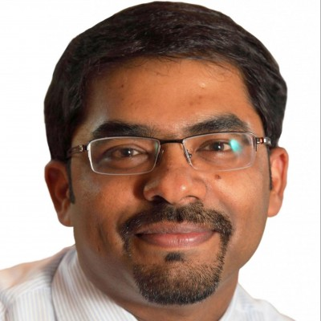

[Madhukar Pai](https://www.forbes.com/sites/madhukarpai/)

[video not shown]